# Example Post

Daniel Sussman

2022-02-23

This file is from `content/post/2021-02-09-example/index.Rmd`. I made it by running `blogdown::new_post("example", ext = ".Rmd")` in the console.

## Just like an RMarkdown

Show code …

```r
library(tidyverse)
msleep %>%
  group_by(vore) %>%
  summarize(`average body weight` = mean(bodywt))
```

```
## # A tibble: 5 × 2
##   vore    `average body weight`
##   <chr>                   <dbl>
## 1 carni                  90.8
## 2 herbi                 367.
## 3 insecti                12.9
## 4 omni                   12.7
## 5 <NA>                    0.858
```

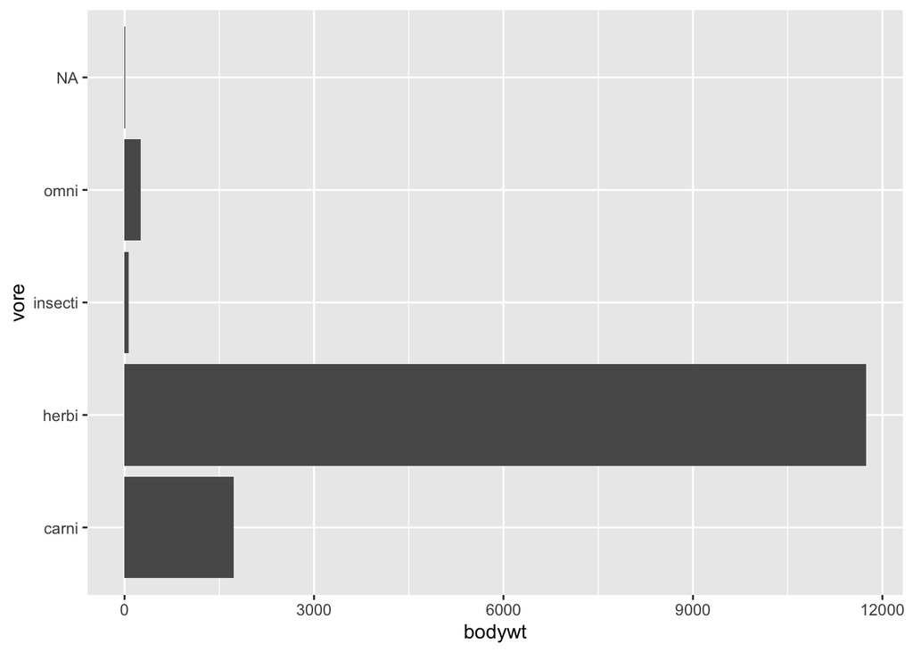

```r
ggplot(msleep, aes(x = bodywt, y = vore)) + geom_col()
```

… or a nicer table …

| vore | average body weight |
| --- | --- |
| carni | 90.75111 |
| herbi | 366.87725 |
| insecti | 12.92160 |
| omni | 12.71800 |
| NA | 0.85800 |

… or make a plot.

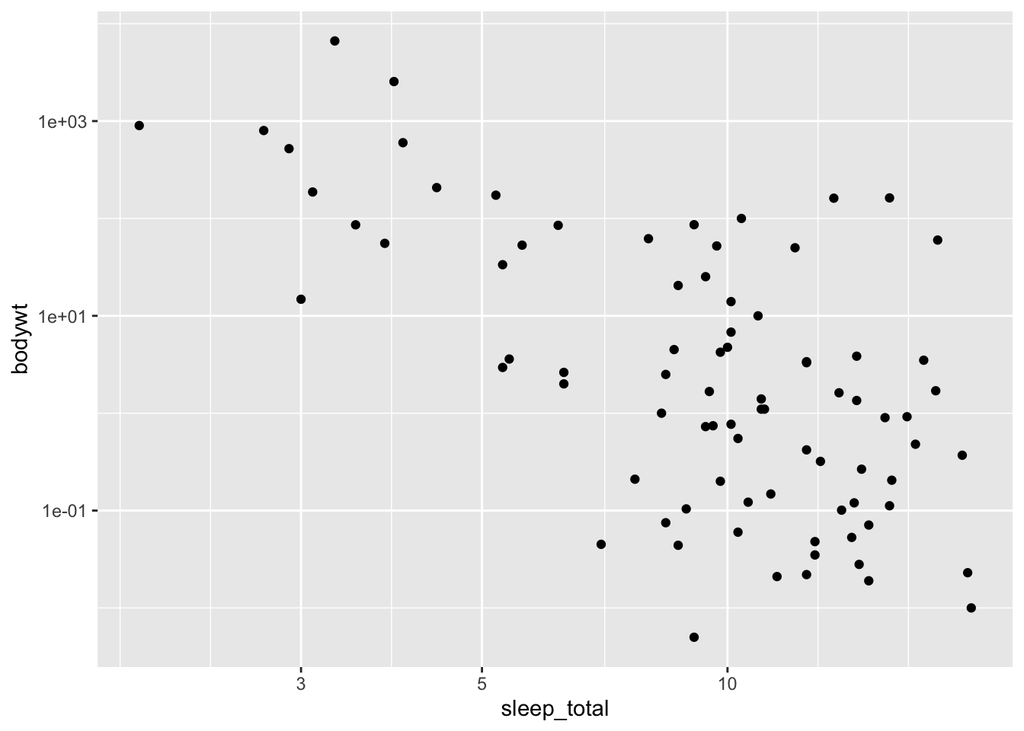

Wow captions too!

```r
ggplot(msleep, aes(x = sleep_total, y = bodywt)) +
  geom_point() + scale_x_log10() + scale_y_log10()
```

I can even put in some math $e^x$ or a displayed equation
$$e^{\pi i} + 1 =
0.$$

# Creating a new post

To create a new post you can run

```r
blogdown::new_post("Post title", ext = ".Rmd")
```

Alternatively, you can use the “Addins” menu.

[figure not shown]

Just make sure to select `.Rmd` for the format so you can include and run `R` code.

## I can’t see my updates

When you want to see how the changes or additions you made will look on the website, you need to run `blogdown::serve_site()` which will knit Rmd files as they change and create a local web server that you can use to preview the site.

If you are not seeing the changes you were hoping for:

1. Check to make sure you are not getting any knitting errors. In the Console, you might something like `Error : Failed to render content/post/2021-02-09-example/index.Rmd` You should look above that for any errors. Usually it will say something like `Quitting from lines 83-84 (index.Rmd)` which can help you to isolate where the error is. (Note, it might not be in the file you have been editing if an error was introduced by a team mate).
2. If you don’t see any errors, it might be that `serve_site()` hasn’t yet recognized the changes you’ve made. To force it to compile you can add a small change to the .Rmd files, like a line break. This will update the modification time on the file which should cause the file to be knitted. Another option is to use Addins -> Touch File (see screenshot above).